# Simple models for beech forests

Prediction A and B

Anthony Davidson

2019-05-16

Help make it better here

Prediction A

Prediction B

At times of low abundance

At times of high abundance

[figure not shown]

# Introduction

At times of high and low abundance there is evidence that mice populations are likely to be under different population pressures. It has been shown that population level processes such as density dependance (competition between individuals for space or resources) when populations are at high abundance (Ruscoe et al. 2005). But at low abundance the demographic processes limiting populations are different, namely resource avaliability rather than competition (Choquenot and Ruscoe 2000). Because these two demographic processes are fundementally different we need to test these times independant of each other. We can then be sure that one phase/season is not obscurring the processes of the other.

# Methods

1. Unequal variances
2. Unequal sample sizes
3. Non-independence removed
- by partitioning groups by phase.
4. Seasons vary through time
- phases don’t

## Low abundance

How to choose what groups to compare?

### Data selection

We have chosen to select trips 10 -> 15 as times of low abundance.

### Data manipulation

This dataset is generated from a combination of the modified data and uses the Bayesian model estimates of abundance but does not use any of the model coefficients currently.

We can summarise the data over valleys, control areas and/or treatments to compare the means and variances.

These comparisons would be fine but there are un-equal replicates and other issues that we need to account for using a ANOVA or mixed model.

### Statistical models

#### Control only

|  | Df | Deviance | Resid. Df | Resid. Dev | F | Pr(>F) |
| --- | --- | --- | --- | --- | --- | --- |
| NULL | NA | NA | 41 | 521.9974 | NA | NA |
| Control | 1 | 0.3211595 | 40 | 521.6763 | 0.0246252 | 0.876094 |

#### Control and valley

|  | Df | Deviance | Resid. Df | Resid. Dev | F | Pr(>F) |
| --- | --- | --- | --- | --- | --- | --- |
| NULL | NA | NA | 41 | 521.9974 | NA | NA |
| Control | 1 | 0.3211595 | 40 | 521.6763 | 0.02414521 | 0.8773175 |
| valley | 1 | 2.9306968 | 39 | 518.7456 | 0.22033379 | 0.6413995 |

#### Control, valley and conditions

|  | Df | Deviance | Resid. Df | Resid. Dev | F | Pr(>F) |
| --- | --- | --- | --- | --- | --- | --- |
| NULL | NA | NA | 41 | 521.9974 | NA | NA |
| Control | 1 | 0.3211595 | 40 | 521.6763 | 0.02385365 | 0.8780753 |
| Valley | 1 | 2.9306968 | 39 | 518.7456 | 0.21767315 | 0.6434824 |
| Conditions | 1 | 7.1230668 | 38 | 511.6225 | 0.52905520 | 0.4714622 |

##### Log(N) for interest

|  | Df | Deviance | Resid. Df | Resid. Dev | F | Pr(>F) |
| --- | --- | --- | --- | --- | --- | --- |
| NULL | NA | NA | 41 | 32.99265 | NA | NA |
| Control | 1 | 0.4348452 | 40 | 32.55780 | 0.5381053 | 0.4677208 |
| Valley | 1 | 0.3415666 | 39 | 32.21623 | 0.4226764 | 0.5195160 |
| Conditions | 1 | 1.5082729 | 38 | 30.70796 | 1.8664336 | 0.1799150 |

#### Full model

|  | Df | Deviance | Resid. Df | Resid. Dev | F | Pr(>F) |
| --- | --- | --- | --- | --- | --- | --- |
| NULL | NA | NA | 41 | 521.9974 | NA | NA |
| Control | 1 | 0.3211595 | 40 | 521.6763 | 0.02386602 | 0.8780659 |
| Valley | 1 | 2.9306968 | 39 | 518.7456 | 0.21778608 | 0.6434683 |
| Conditions | 1 | 7.1230668 | 38 | 511.6225 | 0.52932968 | 0.4714678 |
| Control:Conditions | 1 | 13.7220678 | 37 | 497.9004 | 1.01971496 | 0.3191451 |

## High abundance

### Data selection

### Data manipulation

##### Structuring levels

### Statistical models

|  | Df | Deviance | Resid. Df | Resid. Dev | F | Pr(>F) |
| --- | --- | --- | --- | --- | --- | --- |
| NULL | NA | NA | 27 | 0.9415078 | NA | NA |
| Control | 1 | 0.01339864 | 26 | 0.9281092 | 0.3753487 | 0.545425 |

|  | Df | Deviance | Resid. Df | Resid. Dev | F | Pr(>F) |
| --- | --- | --- | --- | --- | --- | --- |
| NULL | NA | NA | 27 | 0.9415078 | NA | NA |
| Control | 1 | 0.01339864 | 26 | 0.9281092 | 0.4248619 | 0.52046889 |
| Valley | 1 | 0.13969792 | 25 | 0.7884112 | 4.4297289 | 0.04553774 |

|  | Df | Deviance | Resid. Df | Resid. Dev | F | Pr(>F) |
| --- | --- | --- | --- | --- | --- | --- |
| NULL | NA | NA | 27 | 0.9415078 | NA | NA |
| Control | 1 | 0.01339864 | 26 | 0.9281092 | 0.4461291 | 0.51055167 |
| Valley | 1 | 0.13969792 | 25 | 0.7884112 | 4.6514662 | 0.04126034 |
| Conditions | 1 | 0.06761699 | 24 | 0.7207942 | 2.2514161 | 0.14653411 |

|  | Df | Deviance | Resid. Df | Resid. Dev | F | Pr(>F) |
| --- | --- | --- | --- | --- | --- | --- |
| NULL | NA | NA | 27 | 0.9415078 | NA | NA |
| Control | 1 | 0.0133986371 | 26 | 0.9281092 | 0.427644742 | 0.51963243 |
| Valley | 1 | 0.1396979193 | 25 | 0.7884112 | 4.458743082 | 0.04579624 |
| Conditions | 1 | 0.0676169897 | 24 | 0.7207942 | 2.158133685 | 0.15536282 |
| Conditions:control | 1 | 0.0001758777 | 23 | 0.7206184 | 0.005613495 | 0.94092363 |

```
[1]  -9.930135 -12.497761 -13.008412
```

```
[1] 0.9281092 0.7884112 0.7207942
```

| co.effs | Estimate | Std..Error | t.value | Pr...t.. |
| --- | --- | --- | --- | --- |
| (Intercept) | 0.226 | 0.112 | 2.021 | 0.055 |
| ControlYes | -0.063 | 0.094 | -0.664 | 0.513 |
| ValleyHollyford | -0.173 | 0.085 | -2.038 | 0.053 |
| Conditionsrats.removed | 0.100 | 0.067 | 1.500 | 0.147 |

### Model selection

| model.aic | mods.name | mod.dev |
| --- | --- | --- |
| -9.930135 | high.mod1 | 0.9281092 |
| -12.497761 | high.mod2 | 0.7884112 |
| -13.008412 | high.mod3 | 0.7207942 |

# Results

## Low abundance

### Summary

| Observations | 42 |
| --- | --- |
| Dependent variable | N |
| Type | Linear regression |

| χ²(3) | 10.37 |
| --- | --- |
| Pseudo-R² (Cragg-Uhler) | 0.02 |
| Pseudo-R² (McFadden) | 0.00 |
| AIC | 234.19 |
| BIC | 242.88 |

|  | Est. | S.E. | t val. | p |
| --- | --- | --- | --- | --- |
| (Intercept) | 2.53 | 1.93 | 1.31 | 0.20 |
| ControlYes | -0.14 | 1.63 | -0.09 | 0.93 |
| ValleyHollyford | -0.60 | 1.47 | -0.41 | 0.68 |
| Conditionsrats.removed | 0.84 | 1.15 | 0.73 | 0.47 |

Standard errors: MLE

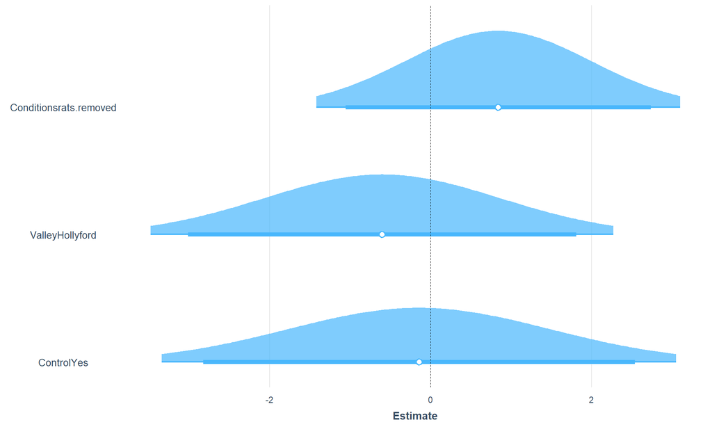

### Plots

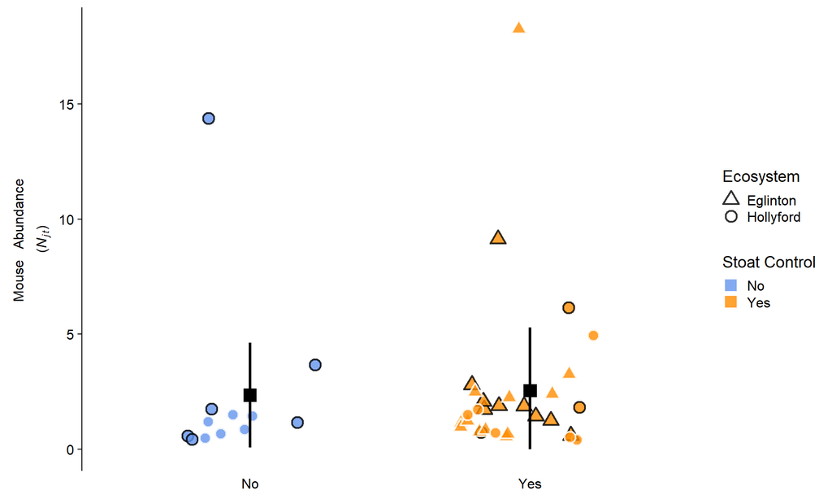

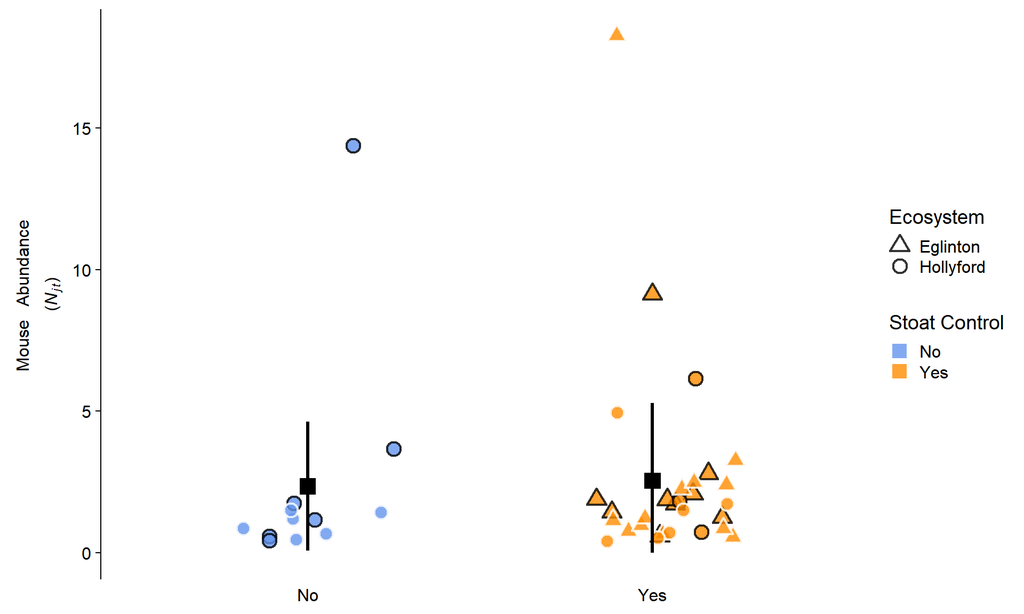

## High abundance

### Summary

|  | Df | Deviance | Resid. Df | Resid. Dev | F | Pr(>F) |
| --- | --- | --- | --- | --- | --- | --- |
| NULL | NA | NA | 27 | 0.9415078 | NA | NA |
| Control | 1 | 0.01339864 | 26 | 0.9281092 | 0.4248619 | 0.52046889 |
| Valley | 1 | 0.13969792 | 25 | 0.7884112 | 4.4297289 | 0.04553774 |

| Observations | 28 |
| --- | --- |
| Dependent variable | n.seed.c |
| Type | Linear regression |

| χ²(3) | 0.22 |
| --- | --- |
| Pseudo-R² (Cragg-Uhler) | -0.32 |
| Pseudo-R² (McFadden) | -0.48 |
| AIC | -13.01 |
| BIC | -6.35 |

|  | Est. | S.E. | t val. | p |
| --- | --- | --- | --- | --- |
| (Intercept) | 0.16 | 0.05 | 3.00 | 0.01 |
| valleyhol | -0.17 | 0.08 | -2.04 | 0.05 |
| controlno control | 0.06 | 0.09 | 0.66 | 0.51 |
| Conditionsrats.removed | 0.10 | 0.07 | 1.50 | 0.15 |

Standard errors: MLE

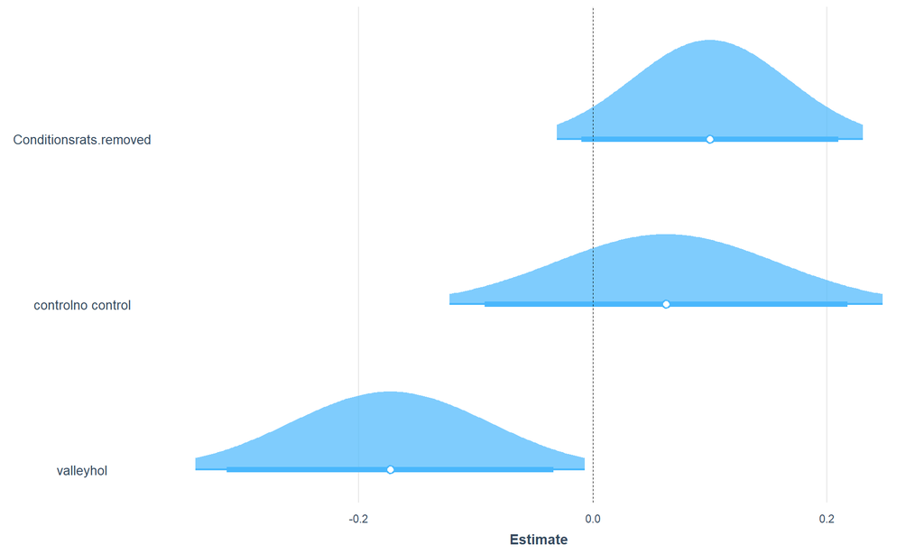

### Plots

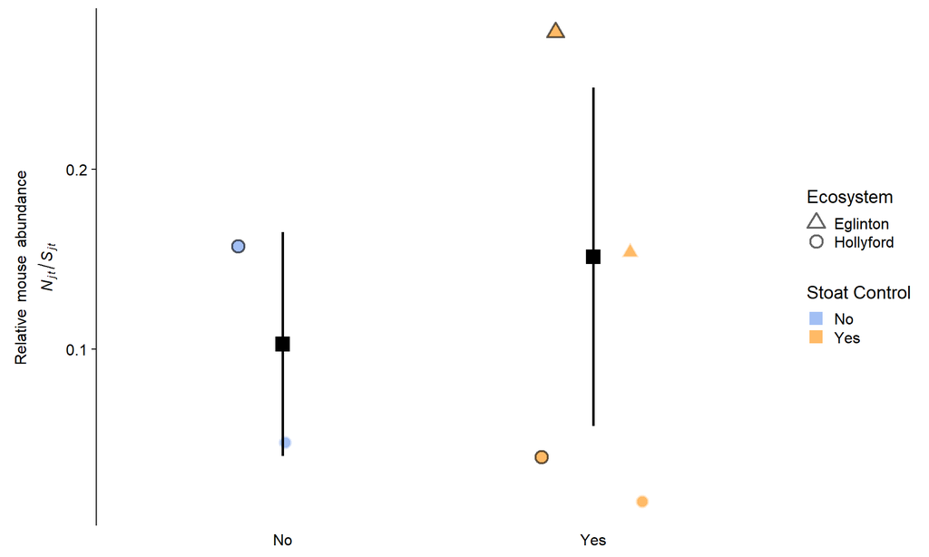

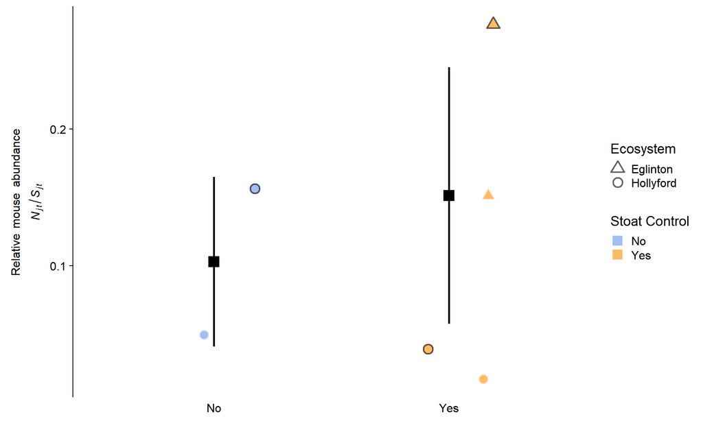

## Save plots

Must be `png`

# Discussion

# References

Choquenot, David, and Wendy A Ruscoe. 2000. “Mouse Population Eruptions in New Zealand Forests: The Role of Population Density and Seedfall.” *Journal of Animal Ecology* 69: 1058–70.

Ruscoe, Wendy A, Joseph S Elkinton, David Choquenot, and Robert B Allen. 2005. “Predation of Beech Seed by Mice: Effects of Numerical and Functional Responses.” *Journal of Animal Ecology* 74: 1005–19. doi:10.1111/j.1365-2656.2005.00998.x.